# Pandas-Bootcamp-Part12

### Data Visualization

#### Plotting in Pandas including :

```
- Bar charts
- Histograms
- Pie Plots + Customizations
- Scatters
- Joint Plots
```

https://www.udemy.com/course/the-ultimate-pandas-bootcamp-advanced-python-data-analysis/learn/lecture/19464898#overview

```python
import numpy as np
import pandas as pd
```

```python
pd.__version__
```

```
'1.0.5'
```

### The Art of Data Visualization

Data Visualization is the practice (and art) of creating a visual representation of information that conveys insight , tells a story or summarizes data.

### The Preliminaries of Matplotlib

```python
#Produce an Array of 400 numbers
#We use numpy to sample 400 samples from random Normal Distribution
x = np.random.normal(size = 400)
```

```python
x
```

```
array([-1.08374969e+00,  1.72153813e+00,  1.33926631e+00,  8.13957714e-01,
       -1.56406091e+00,  6.41590256e-01, -2.11482574e-01,  1.66228519e+00,
        7.97254637e-02, -4.41183193e-01,  1.10660042e-01, -1.13393876e+00,
       -4.95084603e-01,  6.08313625e-01,  2.02510377e+00,  1.12911241e+00,
       -2.51458944e+00,  1.96780560e+00, -3.08896323e-01,  3.14428931e-01,
       -7.35293766e-01,  7.90709572e-01, -1.44948375e+00, -1.32765780e+00,
       -2.56868032e+00, -1.06321673e+00,  3.54935339e-01, -6.03264096e-01,
       -1.13912417e+00, -1.47757922e-01,  1.01389882e-02,  8.04154542e-01,
       -2.68986750e-01, -2.11234936e-01,  8.87569843e-01, -1.09881955e+00,
        4.51101861e-01, -7.71733194e-01, -4.63801623e-01,  2.41935348e-02,
        2.89702718e-01, -3.94671735e-01, -4.18664813e-01, -9.20512261e-01,
       -2.32784294e+00,  2.70056922e-01,  2.00555009e+00, -1.66050226e-01,
       -4.31448666e-01, -9.81475725e-01, -1.04718188e+00, -7.76813934e-01,
       -7.51077020e-01,  1.29804210e+00,  7.75193696e-03,  1.48233394e+00,
       -6.62166729e-01,  8.55774650e-01,  6.07390125e-01,  3.26560085e-01,
        2.24111262e+00, -6.61004884e-01, -2.08749182e-01,  2.39512612e-02,
        9.97928543e-01,  1.42379689e-01,  2.98182652e-01,  9.91056090e-01,
       -7.48279430e-02,  1.11391273e+00, -9.83874875e-01,  1.66920719e-01,
       -4.13252691e-01, -7.08760835e-01,  1.94602934e+00, -1.29941926e+00,
       -3.95483009e-01, -1.65771346e+00, -1.73521810e+00, -1.47464222e+00,
       -1.95130714e+00,  1.03959806e+00,  8.96615337e-01, -4.70322047e-01,
       -5.18886788e-01, -7.80805668e-01,  1.81693785e+00, -6.82158684e-02,
       -1.34038616e+00,  3.06228253e-01,  5.51817356e-01,  1.34927161e+00,
       -2.08692396e-01, -8.30280526e-01,  3.26195921e-01, -5.49189013e-01,
       -6.59040985e-01, -1.44604141e+00,  1.84147820e+00, -1.57348365e-01,
        1.34985777e+00,  1.21930863e+00,  3.44616476e-01, -8.72094449e-01,
        1.23766309e+00,  5.66709694e-01,  2.85580001e-01,  3.82656545e-01,
        2.77923625e-01, -1.02601236e+00,  5.53679147e-01, -5.01671854e-01,
        1.60809676e-01, -8.19939430e-01, -5.41584415e-02,  2.06520708e-01,
        6.15807996e-01,  2.09724902e+00,  7.98518510e-01,  9.89130572e-01,
       -6.36776181e-01,  5.30031640e-01, -7.35660773e-01, -1.48037255e+00,
        8.35734800e-01,  6.16875771e-01,  7.59872234e-01, -2.77254843e-01,
        5.97198093e-01,  1.38100974e+00, -2.43350727e-01,  8.21015845e-01,
        7.47276148e-01, -8.98186461e-01, -8.21585791e-01,  5.41527909e-01,
        2.04562216e-01, -6.87620888e-02,  4.60319628e-01,  1.03110634e+00,
       -5.65659895e-01, -4.75099632e-01,  1.35727272e+00,  6.33828658e-01,
       -1.31814738e+00,  9.50065819e-02, -7.98802611e-01,  3.30758467e-01,
        1.43203033e-01,  9.42868060e-01,  1.16541335e-01,  2.86118428e-01,
       -7.06383001e-02,  1.60515445e+00,  2.46634247e+00, -7.93241490e-01,
        1.99731338e-01, -2.18948981e-01, -5.30557575e-01, -5.32897016e-02,
```

[output cut: 45 more lines]

```
        5.77766383e-01,  2.97517662e-01,  2.68880779e-01, -1.32164598e+00,
       -1.84754980e-01, -1.26895842e+00,  4.82028539e-01, -4.78152887e-01,
       -1.61697136e+00, -6.38371277e-01, -1.14368756e+00, -1.28212236e-01,
       -2.92077971e-01, -4.57519110e-01,  4.44393417e-01,  6.57525456e-01,
        3.28554333e-01,  1.13553507e+00, -2.01520894e+00,  3.61737813e-01,
       -5.20109678e-01, -1.59801114e-01, -7.44210257e-02,  3.83551779e-01,
       -6.53090459e-01,  1.05984668e+00,  1.42600592e-04,  1.26372568e+00,
        4.02246191e-01, -1.06869359e+00, -3.74274314e-01,  5.76155958e-01,
        1.56428833e+00,  6.44011555e-01,  4.07297598e-01, -9.82057551e-03,
        2.06540026e-01,  9.57823818e-01,  1.89838992e-01,  8.06409557e-01,
        5.19872060e-01,  6.77530552e-01,  1.01422052e+00, -9.33412015e-01,
       -5.41264553e-01, -2.51221792e-01, -5.42313837e-01, -1.02981495e+00,
        1.46412998e+00, -6.26468246e-01, -4.32869684e-01,  3.26565439e-02,
       -1.18797969e+00, -8.45103115e-02, -4.56361897e-01,  3.19972023e-01,
       -7.84993876e-02,  1.38379440e+00,  1.38607134e+00,  6.25781208e-01])
```

```python
#To plot this we import pyplot from Matplotlib
import matplotlib.pyplot as plt
```

```python
#another approach
from matplotlib import pyplot as plt
```

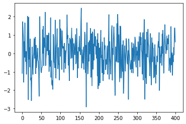

```python
#We plot the data that we generated above
plt.plot(x)
```

Instead of plotting the individual x values, lets go ahead and plot their cumulative sum.

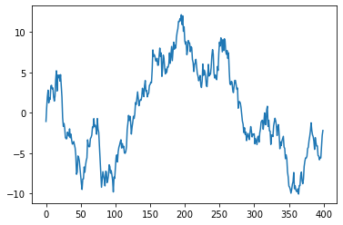

```python
plt.plot(x.cumsum())
```

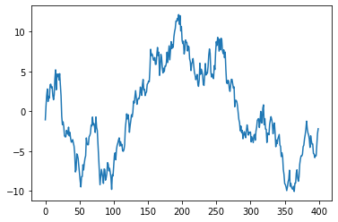

```python
#adding a Semi colon at the end , will conceal this line :
#[<matplotlib.lines.Line2D at 0x1d0f1954160>]
plt.plot(x.cumsum());
```

```python
plt.style.available
```

```
['Solarize_Light2',
 '_classic_test_patch',
 'bmh',
 'classic',
 'dark_background',
 'fast',
 'fivethirtyeight',
 'ggplot',
 'grayscale',
 'seaborn',
 'seaborn-bright',
 'seaborn-colorblind',
 'seaborn-dark',
 'seaborn-dark-palette',
 'seaborn-darkgrid',
 'seaborn-deep',
 'seaborn-muted',
 'seaborn-notebook',
 'seaborn-paper',
 'seaborn-pastel',
 'seaborn-poster',
 'seaborn-talk',
 'seaborn-ticks',
 'seaborn-white',
 'seaborn-whitegrid',
 'tableau-colorblind10']
```

```python
plt.style.use('ggplot')
```

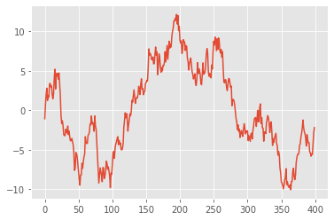

```python
plt.plot(x.cumsum());
```

```python
#We add another series to this plot
y = np.random.normal(size = 400)
```

```python
y
```

```
array([-6.86248241e-01,  2.29202078e+00, -5.58515641e-01,  2.53759048e-01,
        6.92054800e-01,  1.70367826e-01,  7.73278683e-01,  6.65978002e-01,
       -1.15020712e+00, -1.51100436e+00, -1.44162110e-01,  1.58415482e+00,
        1.99115161e+00, -1.20850798e+00, -5.34511498e-01,  6.17998528e-01,
        8.41581212e-01, -1.45543289e-01,  9.93683781e-01, -7.43590412e-01,
        1.58832544e+00,  9.43914631e-01, -3.93062925e-02, -2.15300651e+00,
        4.70568217e-01, -8.51606249e-01, -1.57701384e-01, -9.16564562e-01,
        1.15675704e-01, -1.52824835e+00,  4.18010041e-01,  5.04929525e-01,
        1.79678774e+00, -5.64088559e-01,  5.75638325e-01,  6.16996222e-01,
       -2.59758603e-01,  7.67508744e-01,  1.19089195e+00, -1.44336253e+00,
       -7.41693661e-01, -2.75424941e-02, -1.54827359e+00,  6.29551302e-01,
       -8.84744073e-01, -2.42850628e+00, -8.86588304e-01,  1.28408029e+00,
       -1.90440292e-01,  1.04571855e+00, -8.41250223e-01,  1.25955536e+00,
       -1.44365186e+00,  1.66983096e+00,  5.14899627e-01, -9.76394300e-02,
        3.49800052e+00,  1.47410399e-03,  9.51139145e-01,  2.29558096e-01,
       -2.92020225e-01,  8.58875893e-01, -9.28720927e-01, -6.77067250e-02,
       -1.64164977e-01,  5.13837905e-01,  6.35711972e-01, -6.92563190e-01,
        1.74424470e-01,  1.88443362e+00,  6.01861065e-01,  5.67417596e-01,
       -2.45758174e-01,  2.58061411e-01,  5.98686131e-01,  7.90346918e-01,
        5.08793419e-01, -1.07225112e+00,  1.04689241e+00, -2.71801885e+00,
        8.36943496e-01, -7.17809627e-01, -5.36144877e-01,  2.04169324e+00,
       -8.58630169e-01,  1.02750769e+00,  6.15043438e-01,  7.63430549e-02,
       -1.49948519e+00, -7.32727056e-01,  6.02893648e-01, -1.83905164e+00,
       -3.11835272e+00, -1.05846837e-01,  2.13044656e+00,  6.39760696e-01,
        6.74426390e-01, -1.69544458e-01,  4.39601239e-01,  1.08309416e+00,
       -1.35143870e-01,  5.87982797e-01, -1.01722968e+00,  3.92750820e-01,
        5.22483351e-01,  8.37643226e-02, -7.64231764e-01,  5.45560942e-01,
        1.78375702e+00, -1.65545990e+00, -1.17316921e+00, -1.56920515e-01,
        8.23173095e-02, -5.05326339e-01, -1.23238658e-01,  2.26547209e+00,
       -2.28660729e-01,  6.66439179e-01,  5.60635390e-02, -1.00798605e+00,
        2.68452382e+00,  3.57924327e-01,  5.44692802e-02, -8.45580294e-01,
       -1.84831774e+00,  1.22707956e+00,  1.04692510e+00,  8.59873374e-01,
        5.17734721e-01, -8.38071031e-01,  7.86828234e-02,  3.80532121e-01,
       -2.62006666e+00,  1.49642520e-01,  1.79673558e-02,  2.69707336e+00,
       -1.38938190e+00, -9.97670110e-01, -1.84171231e+00,  1.18270137e+00,
        6.60298524e-03, -2.27318632e+00,  5.74945467e-01, -1.27645721e-01,
        2.76311134e-01,  6.99248343e-01,  7.48680448e-01,  1.31480516e+00,
        2.05970298e+00, -8.49612909e-01, -1.49907671e-01, -4.34544857e-01,
        9.55806726e-02, -1.59809323e+00, -7.05657919e-01, -4.99134099e-01,
        3.49138319e-01, -1.75894774e+00,  1.63661497e-01,  1.04545826e-01,
```

[output cut: 45 more lines]

```
        4.09273505e-01,  9.32347147e-01, -6.91706775e-01, -1.16757130e+00,
       -6.53418823e-02,  1.88905782e-01,  2.28015795e-01, -5.47156960e-01,
        8.63884436e-01,  1.20149690e+00,  3.52781205e-01, -3.21930699e-01,
       -1.12756991e-02, -6.29512719e-01,  6.44097908e-02, -7.58740270e-01,
        2.08264575e-01,  8.54426914e-01,  5.35468268e-01,  1.18335872e+00,
        1.06452120e+00,  6.88599966e-01,  1.21313214e+00,  1.27040606e+00,
       -2.61884661e-02, -1.62968604e+00, -9.04414680e-02,  1.58504433e+00,
       -1.53734005e+00,  5.29708792e-02,  2.88572531e-01,  2.75513922e+00,
        2.67740730e-01,  4.06083071e-01, -2.55214843e-01,  5.81191257e-01,
        1.33217098e+00, -1.02999277e+00,  8.91943233e-01, -9.04428165e-01,
       -2.22569505e-01, -1.46270027e+00,  1.12469645e+00,  7.23719457e-01,
        1.47820931e-01, -2.36866347e-01, -8.39216922e-01,  1.65410848e+00,
        5.52795379e-01, -1.46007733e+00,  6.54272115e-01,  7.87263204e-01,
        7.59736539e-01,  1.03919048e+00, -2.13436945e+00, -4.68945675e-01,
       -6.85421548e-01,  8.27570476e-01,  2.80552708e-01, -1.00193811e+00])
```

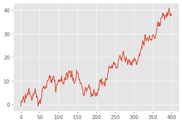

```python
plt.plot(y.cumsum());
```

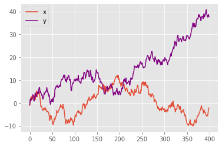

```python
#Now we have both in the same figure
plt.plot(x.cumsum(), label = 'x');
plt.plot(y.cumsum(), color = 'purple' , label= 'y');
plt.legend()
```

```python
#figure holds or contains one or more axes
#Axis refers to the space where the data is plotted
```

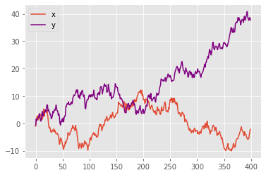

```python
figure , axes = plt.subplots();
axes.plot(x.cumsum(), label = 'x');
axes.plot(y.cumsum(), color = 'purple' , label= 'y');
axes.legend()
```

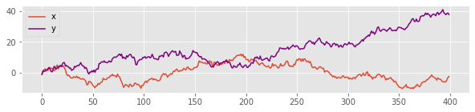

```python
#changing the Size of our Canvas
figure , axes = plt.subplots();
axes.plot(x.cumsum(), label = 'x');
axes.plot(y.cumsum(), color = 'purple' , label= 'y');
axes.legend()

figure.set_size_inches(10,2)
```

That was the difference between axes and figure

### LINE GRAPHS

```python
#A graph that displays a variable over time
#And teh variable could be anything
```

```python
#BrentOilPrices.csv
```

```python
brent = pd.read_csv('BrentOilPrices.csv')
```

```python
brent.head(2)
```

|  | Date | Price |
| --- | --- | --- |
| 0 | 04-Jan-00 | 23.95 |
| 1 | 05-Jan-00 | 23.72 |

```python
brent.Price.min()
```

```
16.51
```

```python
brent.Price.max()
```

```
143.95
```

Price is being plotted on the y-axis

- The range starts from 20 to 140

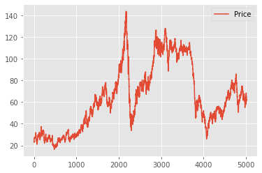

```python
#We can simply call the plot() method on the Dataframe itself
brent.plot()
```

```python
brent.shape
```

```
(5016, 2)
```

count is being plotted on the x-axis

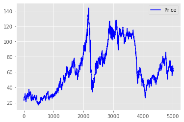

```python
brent.plot(color = 'blue');
```

```python
tech = pd.read_csv('tech_giants.csv')
```

```python
tech.head(3)
```

|  | date | month | year | day | name | open | close | high | low | volume | volume_type |
| --- | --- | --- | --- | --- | --- | --- | --- | --- | --- | --- | --- |
| 0 | 2014-01-02 | 1 | 2014 | 2 | FB | 54.86 | 54.71 | 55.22 | 54.19 | 43257622 | medium |
| 1 | 2014-01-02 | 1 | 2014 | 2 | AAPL | 79.38 | 79.02 | 79.58 | 78.86 | 8398851 | low |
| 2 | 2014-01-02 | 1 | 2014 | 2 | GOOGL | 557.73 | 556.56 | 558.88 | 554.13 | 1822719 | medium |

- This dataset consists of Stock Prices

We will re-import this data and parse the "date" column into datetime

- And set the datetime as index
- we set the index_col to "0" column , that is the first column should act as index
- We also set the "parse_dates" parameter to True

```python
tech = pd.read_csv('tech_giants.csv', index_col = 0 , parse_dates = True)
```

```python
tech.head(3)
```

| date | month | year | day | name | open | close | high | low | volume | volume_type |
| --- | --- | --- | --- | --- | --- | --- | --- | --- | --- | --- |
| 2014-01-02 | 1 | 2014 | 2 | FB | 54.86 | 54.71 | 55.22 | 54.19 | 43257622 | medium |
| 2014-01-02 | 1 | 2014 | 2 | AAPL | 79.38 | 79.02 | 79.58 | 78.86 | 8398851 | low |
| 2014-01-02 | 1 | 2014 | 2 | GOOGL | 557.73 | 556.56 | 558.88 | 554.13 | 1822719 | medium |

```python
#We will create a small series of only the series of 'close' prices and 'dates' that we are looking to plot
fb = tech.loc[tech.name == 'FB' , 'close'].rename('Facebook')
```

```python
fb.head(4)
```

```
date
2014-01-02    54.71
2014-01-03    54.56
2014-01-06    57.20
2014-01-07    57.92
Name: Facebook, dtype: float64
```

Now we have a sequence of prices , a sequence of dates and the Series Name is "Facebook"

- The length of the Series is 1421

```python
#Lets do the same thing for the other tech companies
msft = tech.loc[tech.name == 'MSFT' , 'close'].rename('Microsoft')
aapl = tech.loc[tech.name == 'AAPL' , 'close'].rename('Apple')
```

At this stage we have three Series : "fb" , "msft" , "aapl"

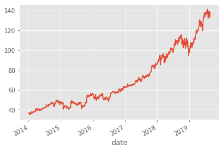

```python
#We want to see the Microsoft Price Graph
msft.plot();
```

#### How do we plot all three of them together from within Pandas

When we plot it on a Dataframe , Pandas automatically plots all the columns in separate line Graphs for us. Our plan is to get a DataFrame that only contains the Sequence of prices that we want to Plot

- Now that we have all three Prices with datetime index, its quite easy to put them together in a DataFrame using the Pandas concat() method we explored prev.

```python
pd.concat([fb , msft , aapl] , axis = 1)
```

| date | Facebook | Microsoft | Apple |
| --- | --- | --- | --- |
| 2014-01-02 | 54.71 | 37.16 | 79.02 |
| 2014-01-03 | 54.56 | 36.91 | 77.28 |
| 2014-01-06 | 57.20 | 36.13 | 77.70 |
| 2014-01-07 | 57.92 | 36.41 | 77.15 |
| 2014-01-08 | 58.23 | 35.76 | 77.64 |
| ... | ... | ... | ... |
| 2019-08-19 | 186.17 | 138.41 | 210.35 |
| 2019-08-20 | 183.81 | 137.26 | 210.36 |
| 2019-08-21 | 183.55 | 138.79 | 212.64 |
| 2019-08-22 | 182.04 | 137.78 | 212.46 |
| 2019-08-23 | 177.75 | 133.39 | 202.64 |

1421 rows × 3 columns

```python
dfs = pd.concat([fb , msft , aapl] , axis = 1)
```

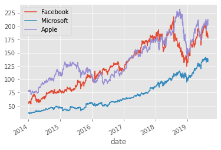

```python
dfs.plot();
```

- We managed to isolate only the price series
- Then we reshaped the data into a new dataframe that we are now ready to plot
- So, without importing Matplotlib and calling "plot()" multiple times, we have a Line graph of three distinct Price series plotted in one figure using a single line of code

#### We can break up this view into separate Sub plots , within the same figure.

- we can set the subplots parameter to True

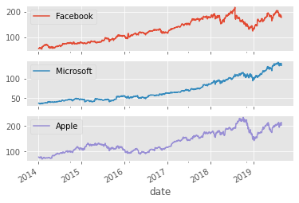

```python
dfs.plot(subplots = True);
```

Now we get three axes withon one Figure

- change the Line width

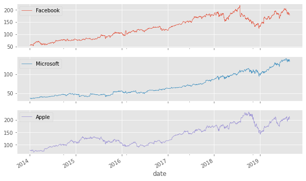

```python
dfs.plot(subplots = True, linewidth = 0.7 , figsize = (10,6));
```

### BAR Graphs

https://www.udemy.com/course/the-ultimate-pandas-bootcamp-advanced-python-data-analysis/learn/lecture/19498584#overview

```python
boston = pd.read_csv('2017BostonMarathonTop1000.csv')
```

We use Bar charts when we need to plot Numerical value across different levels of a Categorical value for example : "Number of Ivy League Students by State" , "Number of Marathon runners by Age"

### Marathon runners by Age(Category)

'Age' is going to be our categorical value. We are going to count the number of runners within that Age and that is going to be our Numerical value.

- Lets start by isolating our Categorical variable.

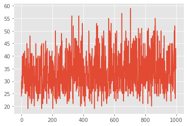

```python
#We we call plot on this "Age" variable , we get a very Odd Line graph that shows the Ages for all our 1000 runners
#We do get a plot but it conveys nothing
boston.Age.plot();
```

- We need to go from a sequence of integers to a combination of numeric and Categorical values

```python
#When we look at value_counts we get a frequency table
#The original unique values are on the left (which is like the Index )and the "Number of times each value
#shows up" is on the Right
boston.Age.value_counts()
```

```
28    60
30    60
26    56
29    56
32    53
36    50
27    49
33    49
35    48
31    44
25    41
34    37
39    35
37    33
40    33
```

[output cut: 25 more lines]

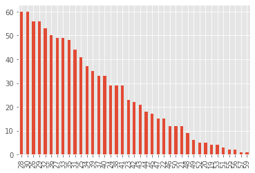

```python
boston.Age.value_counts().plot(kind = 'bar');
```

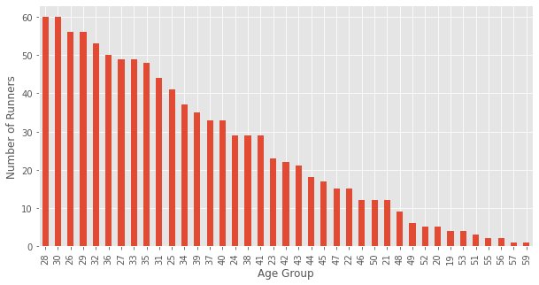

```python
#Lets change the Figure size so that the Ages are not so squished on the X-Axis
ax = boston.Age.value_counts().plot(kind = 'bar' , figsize = (10 , 5));
ax.set_xlabel('Age Group');
ax.set_ylabel('Number of Runners');
```

- Visually we can kind of see that the Number of 30 year olds is almost double that of the 40 year olds.
- Look at the X-axis is not sorted
- We got the data in this order because the value_counts() method automatically sorts the output in decreasing order of Frequency and in order to turn that default behaviour OFF, we can set the sort parameter to "False" for value_counts

```python
boston.Age.value_counts(sort = False)
```

```
19     4
20     5
21    12
22    15
23    23
24    29
25    41
26    56
27    49
28    60
29    56
30    60
31    44
32    53
33    49
```

[output cut: 25 more lines]

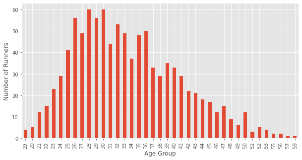

```python
#Lets change the Figure size so that the Ages are not so squished on the X-Axis
ax = boston.Age.value_counts(sort = False).plot(kind = 'bar' , figsize = (10 , 5));
ax.set_xlabel('Age Group');
ax.set_ylabel('Number of Runners');
```

- Now we get ordered Ages
- We see the peak at 27-33 Age group, which indicates most runners come from 27-33 Age group

#### How to produce Horizontal Bar charts

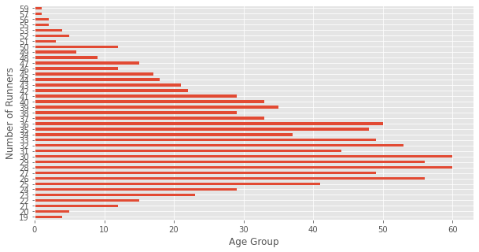

```python
#kind = barh
#Lets change the Figure size so that the Ages are not so squished on the X-Axis
ax = boston.Age.value_counts(sort = False).plot(kind = 'barh' , figsize = (10 , 5));
ax.set_xlabel('Age Group');
ax.set_ylabel('Number of Runners');
```

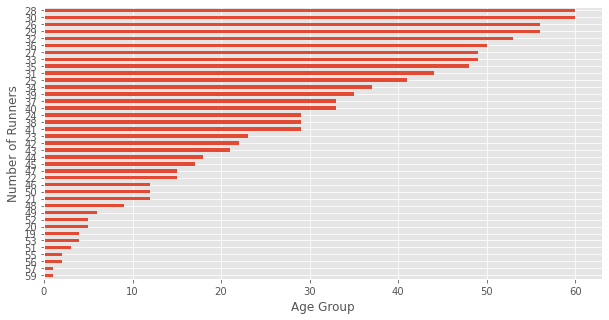

```python
#Sorted in Descending order
ax = boston.Age.value_counts(ascending = True).plot(kind = 'barh' , figsize = (10 , 5));
ax.set_xlabel('Age Group');
ax.set_ylabel('Number of Runners');
```

- But in our use case with so many categories, its getting a bit difficult to process all of these output
- It would be better with fewer categories

Examples could be :

```
- Wine consumption by continent
- XBOX sales by country
- Marathon runners by Gender
```

#### Marathon Runners by Gender

```python
#Lets see what the breakdown is
```

```python
boston.head(2)
```

|  | Name | Age | M/F | City | State | Country | Official Time | Overall | Gender | Years Ran |
| --- | --- | --- | --- | --- | --- | --- | --- | --- | --- | --- |
| 0 | Kirui, Geoffrey | 24 | M | Keringet | NaN | KEN | 2:09:37 | 1 | 1 | NaN |
| 1 | Rupp, Galen | 30 | M | Portland | OR | USA | 2:09:58 | 2 | 2 | NaN |

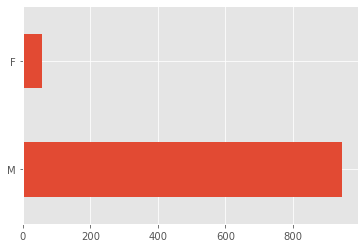

```python
#Lets convert that to Frequency table in one go
boston['M/F'].value_counts().plot(kind='barh');
```

- Looks like top 1000 is clearly dominated by "Male Runners"
- Instead of Raw data , we can convert this to percentages

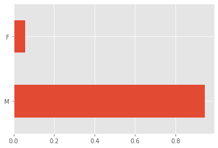

```python
#normalize = True
boston['M/F'].value_counts(normalize = True).plot(kind='barh');
```

#### When to use PIE charts:

- Just like BAR charts , PIE charts also show a numerical amount against different levels of a Categorical value. With PIE charts , the focus is on attributing a TOTAL amount into its components.
- Whereas with BAR charts the focus is usually only to show absolute amounts in each category side by side rectangular BAR layout.

```python
games = pd.read_csv('games_sales.csv')
```

#### What is the Market share for each Platform in North America

```python
#We are going to need the "NA Sales" series here
```

```python
games.head(3)
```

|  | Name | Platform | Year | Genre | Publisher | NA_Sales | EU_Sales | JP_Sales | Other_Sales | Global_Sales |
| --- | --- | --- | --- | --- | --- | --- | --- | --- | --- | --- |
| 0 | Kinect Adventures! | X360 | 2010.0 | Misc | Microsoft Game Studios | 14.97 | 4.94 | 0.24 | 1.67 | 21.82 |
| 1 | Grand Theft Auto V | PS3 | 2013.0 | Action | Take-Two Interactive | 7.01 | 9.27 | 0.97 | 4.14 | 21.40 |
| 2 | Grand Theft Auto V | X360 | 2013.0 | Action | Take-Two Interactive | 9.63 | 5.31 | 0.06 | 1.38 | 16.38 |

```python
#We apply an aggregate SUM() to get a view of the North American Market
games.NA_Sales
```

```
0       14.97
1        7.01
2        9.63
3        9.03
4        9.67
        ...
3138     0.00
3139     0.01
3140     0.01
3141     0.00
3142     0.00
Name: NA_Sales, Length: 3143, dtype: float64
```

```python
games.groupby('Platform').NA_Sales.sum()
```

```
Platform
PS3     392.26
PS4      96.80
X360    601.05
XOne     83.19
Name: NA_Sales, dtype: float64
```

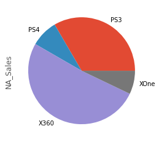

```python
games.groupby('Platform').NA_Sales.sum().plot(kind = 'pie');
```

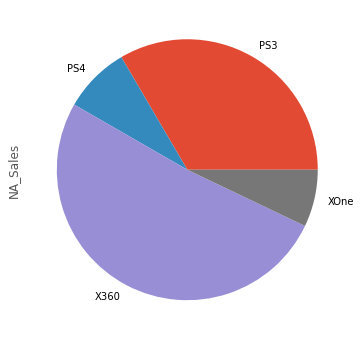

```python
games.groupby('Platform').NA_Sales.sum().plot(kind = 'pie' , figsize = (6,6));
```

- We see XBOX dominating the North American Market

```python
games.head(4)
```

|  | Name | Platform | Year | Genre | Publisher | NA_Sales | EU_Sales | JP_Sales | Other_Sales | Global_Sales |
| --- | --- | --- | --- | --- | --- | --- | --- | --- | --- | --- |
| 0 | Kinect Adventures! | X360 | 2010.0 | Misc | Microsoft Game Studios | 14.97 | 4.94 | 0.24 | 1.67 | 21.82 |
| 1 | Grand Theft Auto V | PS3 | 2013.0 | Action | Take-Two Interactive | 7.01 | 9.27 | 0.97 | 4.14 | 21.40 |
| 2 | Grand Theft Auto V | X360 | 2013.0 | Action | Take-Two Interactive | 9.63 | 5.31 | 0.06 | 1.38 | 16.38 |
| 3 | Call of Duty: Modern Warfare 3 | X360 | 2011.0 | Shooter | Activision | 9.03 | 4.28 | 0.13 | 1.32 | 14.76 |

#### Does PlayStation (PS) has a larger Market Share in Japan

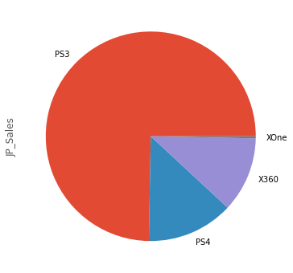

```python
games.groupby('Platform').JP_Sales.sum().plot(kind = 'pie' , figsize = (6,6));
```

#### What if we call plot() on a dataframe

(A Data Frame is a datastructure that has multiple Columns )

```python
#We will begin by indexing the main dataFrame
#We select all Rows and NA_sales , JP_sales , 'Platform'
#This gives us a Dataframe Slice
games.loc[: , ['NA_Sales' , 'JP_Sales' , 'Platform']]
```

|  | NA_Sales | JP_Sales | Platform |
| --- | --- | --- | --- |
| 0 | 14.97 | 0.24 | X360 |
| 1 | 7.01 | 0.97 | PS3 |
| 2 | 9.63 | 0.06 | X360 |
| 3 | 9.03 | 0.13 | X360 |
| 4 | 9.67 | 0.11 | X360 |
| ... | ... | ... | ... |
| 3138 | 0.00 | 0.00 | X360 |
| 3139 | 0.01 | 0.00 | XOne |
| 3140 | 0.01 | 0.00 | XOne |
| 3141 | 0.00 | 0.00 | PS4 |
| 3142 | 0.00 | 0.00 | XOne |

3143 rows × 3 columns

```python
#Group by Platform
```

```python
games.loc[: , ['NA_Sales' , 'JP_Sales' , 'Platform']].groupby('Platform')
```

```
<pandas.core.groupby.generic.DataFrameGroupBy object at 0x000001D0F6FDB1C0>
```

```python
#Find the sum() of each Platform's Sales in North America and Japan
```

```python
games.loc[: , ['NA_Sales' , 'JP_Sales' , 'Platform']].groupby('Platform').sum()
```

| Platform | NA_Sales | JP_Sales |
| --- | --- | --- |
| PS3 | 392.26 | 79.99 |
| PS4 | 96.80 | 14.30 |
| X360 | 601.05 | 12.43 |
| XOne | 83.19 | 0.34 |

- We see the SUM of Sales in both NA and JP

```python
games.loc[: , ['NA_Sales' , 'JP_Sales' , 'Platform']].groupby('Platform').sum().plot(kind = 'pie')
```

```
---------------------------------------------------------------------------
ValueError                                Traceback (most recent call last)
<ipython-input-107-010846f2c661> in <module>
----> 1 games.loc[: , ['NA_Sales' , 'JP_Sales' , 'Platform']].groupby('Platform').sum().plot(kind = 'pie')

~\Anaconda3\lib\site-packages\pandas\plotting\_core.py in __call__(self, *args, **kwargs)
    796             if isinstance(data, ABCDataFrame):
    797                 if y is None and kwargs.get("subplots") is False:
--> 798                     raise ValueError(
    799                         f"{kind} requires either y column or 'subplots=True'"
    800                     )

ValueError: pie requires either y column or 'subplots=True'
```

- We get a VALUE Error :either y column or 'subplots=True'

```python
import pandas as pd
import numpy as np
```

```python
games = pd.read_csv('games_sales.csv')
```

[figure not shown]

```python
#Lets specify the "y" argument
games.loc[: , ['NA_Sales' , 'JP_Sales' , 'Platform']].groupby('Platform').sum().plot(kind = 'pie' , y = 'NA_Sales');
```

#### We are still not Convinced

- We want to plot two pie charts side by side

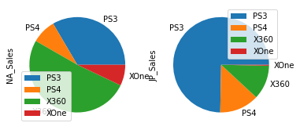

```python
games.loc[: , ['NA_Sales' , 'JP_Sales' , 'Platform']].groupby('Platform').sum().plot(kind = 'pie' , subplots = True);
```

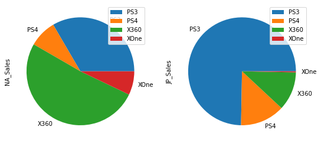

```python
games.loc[: , ['NA_Sales' , 'JP_Sales' , 'Platform']].groupby('Platform')\
.sum().plot(kind = 'pie' , subplots = True , figsize =(9,9));
```

- Our figure contains two subplots each attributing the Total Sales in North America and Japan
- While XBOX attracts the biggest share of Game Sales in North America , Playstation absolutely dominates in Japan
- We see that the Market Share of PS3 and PS4 combined is something close to 80 to 90 %
- We use pie plots when we want to show the Total amount is split between component parts
- We split how much each Platform contributes to the North American sales
- We see that PlayStation dominates in JP and XBOX dominates in NA